# Computing Genomic Relationships according to VanRaden PM (2008)

Solomon Antwi Boison (BOKU university)

2014-09-10

see: *VanRaden PM (2008): Efficient methods to compute genomic predictions. Journal of Dairy Sci., 91:4414-4423*  
G was computed as $G = \frac{Z Z'}{ 2 \sum pi(1-pi)}$

Z was computed as $Z = M - P$

where **M** genotype matrix of gene-content *(0/1/2)*. it was **0** if the genotype of an individual for SNP *i* was homozygous **11**, was **1** if heterozygous **(12, or 21)**, or **2** if the genotype was homozygous **22**. where **P** is a matrix containing the 2 *x* the frequency of the second allele for SNP *i* (i.e. *2pi* ). *Allele frequencies are computed from the data*.

**Description of the R-function**  
Rscript (`vanRaden_G.R`) contains the code for the computation of pairwise Genomic relationship according to VanRaden P. (2008). when the script is sourced, the function name is `GRM_vanRaden`.  
The function argument are given in detail below. Please try and go through the information below which tries to provide comprehensive explanations.

After sourcing the Rscript (vanRaden_G.R), **GRM** can be computed with the following R-function. `GRM_vanRaden(genofile, genoformat, outputformat, outputname, nIID, missinggeno, plots)`.  
*important NOTE*:  
1. that only numeric allele codings are allowed (alleles – 11/12/22 or genotypes – 0/1/2).  
2. missing genotypes are allowed ( however code missing genotypes as NA. adhoc imputations is done by replacing missing values with the column mean).  
**++++++++++++++++++++ argument ++++++++++++++++++++++++**:  
1. *genofile* === Name of the genotype file: it can be an “external file” or “R-object”  
2. *genoformat* === genotype file format. four (4) format types are allowed (**ped,genotypes,Robj_ped,Robj_genotypes**)  
3. *outputformat* === three (3) output format types are allowed (**ASREML,dense,matrix**)  
4. *outputname* === output name of final file. This will be the text file outputted to your current directory  
5. *nIID* === number of animals in dataset, slightly higher value increase speed of reading genotype data  
6. *missinggeno* === **TRUE/T** or **FALSE/F** if there are missing genotypes, missing genotype should be NA 7. *plots* === **TRUE/T** or **FALSE/F**  
**Some specific explanation of Argument 2 and 3**  
*Explanation for argument 2*  
genoformat allows for different file format to be specified  
1 **ped** —– PLINK ped file format, or linkage file format see PLINK.  
format: FamID ID sire dam sex pheno SNP1_allele1 SNP1_allele2 SNP2_allele1 SNP2_allele2 ………  
2. **genotypes**  
format: FamID ID sire dam sex pheno SNP1 SNP2 ………  
3 & 4. **Robj_ped** or **Robj_genotypes**  
These are R-object, for example if you already have imported the dataset in R. Depending on the format, if it an R-object in **ped** style the use **Robj_ped**, else use **Robj_genotypes**.  
format: **Robj_ped** – ID SNP1_allele1 SNP1_allele2 SNP2_allele1 SNP2_allele2 …..  
format: **Robj_genotypes** – ID SNP1 SNP2 ………  
**Explanation for argument 3**:  
Three (3) output format are allowed.  
1. **ASREML** == ASREML for a relationship matrix (free flow format, only the diagonal element and the lower triangle is present) — fast to export —  
2. **dense** == free flow format with all pairwise relationship present — slow to export —  
3. **matrix** == pairwise relationship in a matrix format. — faster to export —  
Sequential explanation of how to implement vanRaden formulae in R

```r
# read in a genotype file (only genotypes and are coded as 0,1,2)
M <- read.table("example/ex_1k.genotype")[,-c(1:6)]  # first six non-important columns deleted

# calculate allele frequency of the second allele (i.e. allele frequency of genotype coded as 2)
  #simple example for just 1 SNP with 5 genotype animals
  SNP1 <- matrix(c(0,1,1,2,2))  ##eqivalent to *AA,AB,AB,BB,BB*
  #allele frequency of p (i.e. allele 2); sum the values in SNP1 divided by 2*nrow(SNP1)
  # this expression is equivalent to taking the mean of the column and dividing it by 2
  p=mean(SNP1)/2;  q=1-p

# calculate 'p' and 'q' for the geno data
p=(apply(M,2,mean))/2;   q=1-p;    pt2=2*p;
#subtract 2*p from M
Z=t(apply(M,1,function(x) x-pt2))
# calculate scaler K
K <- 2*sum(p*q)
# compute G
G <- (Z %*% t(Z))/K
```

Optimise way to implement vanRaden formulae in R

```r
# read in a genotype file (only genotypes and are coded as 0,1,2)
M <- read.table("example/ex_1k.genotype")[,-c(1:6)] # first six non-important columns deleted
M <- scale(x=M,center=T,scale=F)
K<-sum(apply(X=M,FUN=var,MARGIN=2))
G <- tcrossprod(M)/K
```

Now let look at the comprehensive script provided source the Rscript

```r
# Set working directory to the correct path
# soucre the file
source("vanRaden_G.R")
```

**Let use the script to try out some examples** *for example 1*:  
computing GRM using PLINK - PED file format as input marker data  
output GRM format is ‘*matrix*’ type and ‘*ASREML*’

```
##
## ....... Importing genotype file ..........
## ....... Genotype file imported ..........
##
## ....... file processing for GRM computation started ..........
## ....... G computed according to vanRaden (2008) ..........
##
## ....... Output file preparation started ..........
## ....... Output file exported ex1_matrix.grm ..........
```

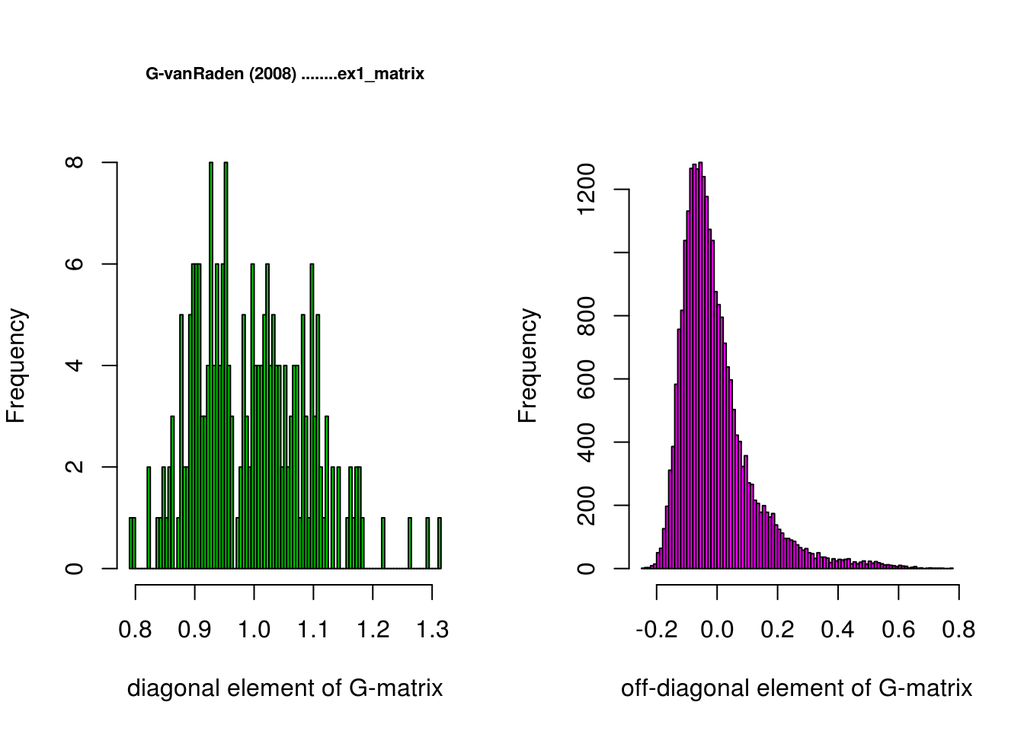

```r
# Matrix format

ex1_G <- GRM_vanRaden(genofile="example/ex_1k.ped",genoformat="ped",outputformat="matrix",outputname="ex1_matrix",nIID=300,missinggeno=F,plots=T)
```

```r
#ASREML
#ex1_G <- GRM_vanRaden(genofile="example/ex_1k.ped",genoformat="ped",outputformat="ASREML",outputname="ex1_asreml",nIID=300,missinggeno=F,plots=T)

# You can try the 5k and 23k dataset
# calcG <- GRM_vanRaden(genofile="example/ex_5k.ped",genoformat="ped",outputformat="matrix",outputname="ex1_5k_matrix",nIID=300,missinggeno=F,plots=T)

#calcG <- GRM_vanRaden(genofile="example/ex_23k.ped",genoformat="ped",outputformat="matrix",outputname="ex1_23k_matrix",nIID=300,missinggeno=F,plots=T)
```

*for example 2*:  
computing GRM using PLINK - genotype file format as input marker data  
output GRM format is ‘*matrix*’ type

```
##
## ....... Importing genotype file ..........
## ....... Genotype file imported ..........
##
## ....... file processing for GRM computation started ..........
## ....... G computed according to vanRaden (2008) ..........
##
## ....... Output file preparation started ..........
## ....... Output file exported ex2_matrix.grm ..........
```

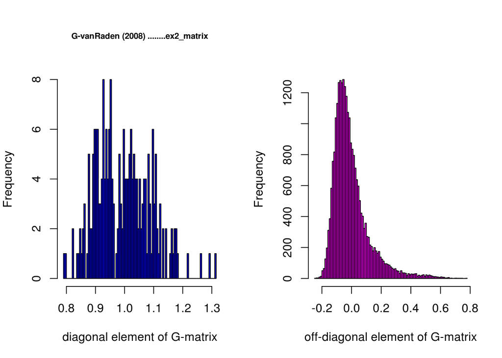

```r
ex2_G <- GRM_vanRaden(genofile="example/ex_1k.genotype",genoformat="genotypes",
                      outputformat="matrix",outputname="ex2_matrix",nIID=300,missinggeno=F,plots=TRUE)
```

*for example 3*:  
computing GRM using **R-object in ped format** as input marker data  
output GRM format is ‘*matrix*’ type

```
##
## ....... file processing for GRM computation started ..........
##
## ....... G computed according to vanRaden (2008) ..........
##
## ....... Output file preparation started ..........
## ....... Output file exported ex3_matrix.grm ..........
```

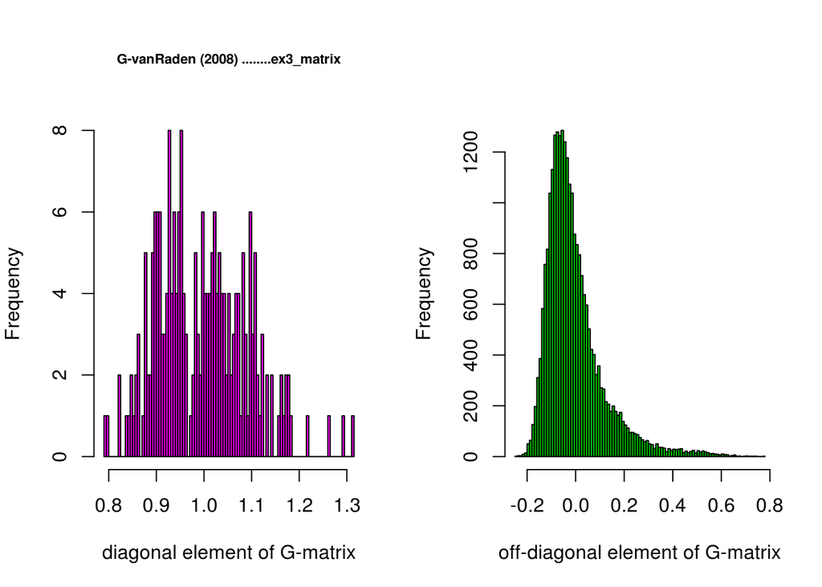

```r
# readin genotype file in R, delete redundent columns except ID and specify this file for function
geno <- read.table("example/ex_1k.ped")[,-c(1,3:6)]
ex3_G <- GRM_vanRaden(genofile="geno",genoformat="Robj_ped",outputformat="matrix",outputname="ex3_matrix",nIID=300,missinggeno=F,plots=TRUE)
```

*for example 4*:  
computing GRM using **R-object in genotype format** as input marker data  
output GRM format is ‘*matrix*’ type

```
##
## ....... file processing for GRM computation started ..........
##
## ....... G computed according to vanRaden (2008) ..........
##
## ....... Output file preparation started ..........
## ....... Output file exported ex4_asreml.grm ..........
```

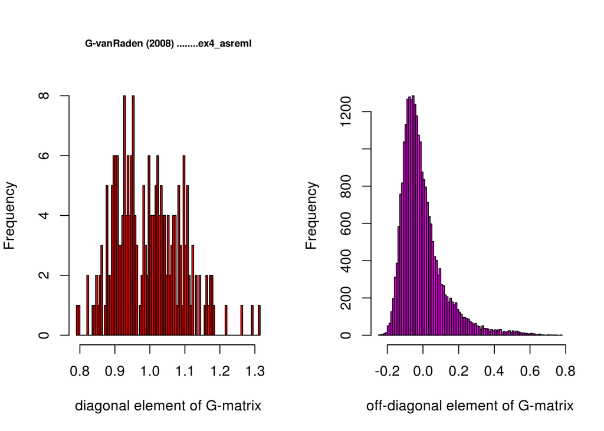

```r
geno <- read.table("example/ex_1k.genotype")[,-c(1,3:6)]
ex4_G <- GRM_vanRaden(genofile="geno",genoformat="Robj_genotypes",outputformat="matrix",outputname="ex4_asreml",nIID=300,missinggeno=F,plots=TRUE)
```

Note that all the G are the same.  
Eigen value decomposition of G can be obtained and plots made using the `eigen function` on **G**  
heatmap of G can also be created

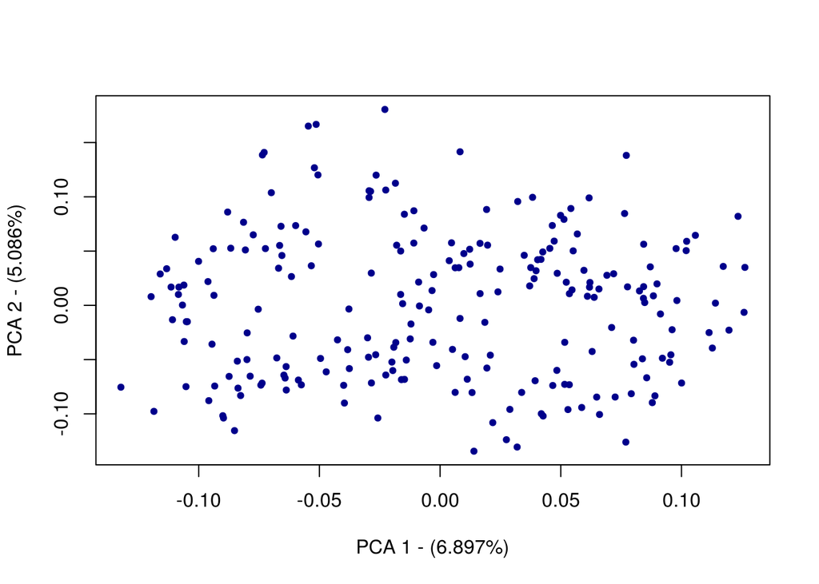

```r
eigen_G <- eigen(ex1_G)
pca_G <- eigen_G$vectors
pervarPCA <- round((eigen_G$values/sum(eigen_G$values))*100,3)
plot(x=pca_G[,1],y=pca_G[,2],pch=20,col="darkblue",
     xlab=c(paste("PCA 1 - (",pervarPCA[1],"%)",sep="")),
     ylab=c(paste("PCA 2 - (",pervarPCA[2],"%)",sep="")))
```

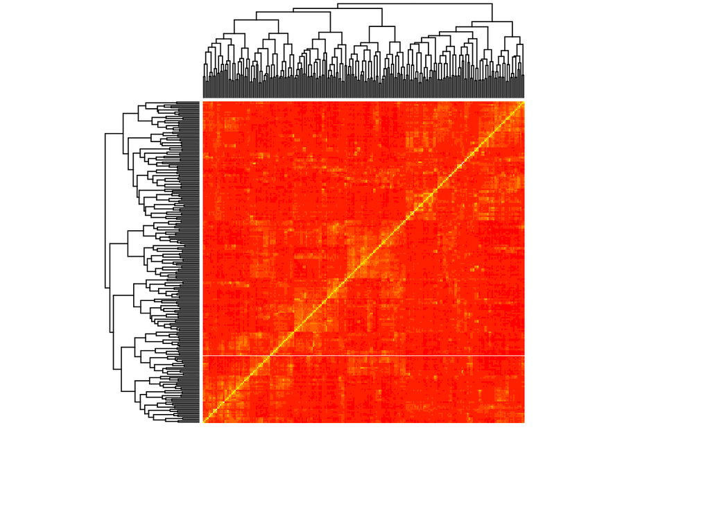

```r
heatmap(ex1_G,labRow=F,labCol=F,keep.dendro=T)
```

```r
#ex5MBCB_G <- GRM_vanRaden(genofile="example/ex_diffPOP.genotypes",genoformat="genotypes",outputformat="matrix",outputname="ex4_asreml",nIID=4000,missinggeno=F,plots=TRUE)

#eigen_G <- eigen(ex5MBCB_G)
#pca_G <- eigen_G$vectors
#pervarPCA <- round((eigen_G$values/sum(eigen_G$values))*100,3)
#plot(x=pca_G[,1],y=pca_G[,2],pch=20,col="darkblue",
#     xlab=c(paste("PCA 1 - (",pervarPCA[1],"%)",sep="")),
#     ylab=c(paste("PCA 2 - (",pervarPCA[2],"%)",sep="")))
```